# Cacao Percentage and Chocolate ratings

# Introduction

The average person consumes just under 2 pounds of chocolate per year worldwide. Around the world, across numerous chocolate manufacturers in each country, what distinguishes highly rated chocolate? Is it the percentage of cacao in each bar? This study explores multiple factors that go into the creation of a chocolate bar and chocolate ratings using data from 2,600 reviews by the Manhattan Chocolate Society. We would like to know if the cacao percentage has a large influence on these ratings and if it’s possible to use the cacao percentage to predict the rating given to the chocolate bar.

# Background

### Dataset Information

This dataset includes 2,600 ratings of plain (non-flavored) chocolate bars produced by chocolate manufacturers around the world. The ratings are conducted by the Manhattan Chocolate society, who conduct research on chocolate production in order to produce innovative, high quality chocolate.

#### Data Collection for Rating Column

Each row of data represents a professional’s review on a type of chocolate. Professionals were sent to try this specific chocolate, and their ratings were used as the data in the dataset. In addition to the members of the Manhattan Chocolate Society, chocolate makers, authors, and experts were invited to partake in the tastings.Ratings were conducted on a five point scale:

**1.0 - 1.9: Unpleasant**

**2.0 - 2.9: Disappointing**

**3:0 - 3.49: Recommended**

**3.5 - 3.9: Highly Recommended**

**4.0 - 5.0 : Outstanding**

To determine the rating, the below factors were considered:

**Flavor:** How intense the cacao tastes (mild-moderate-strong), the roast of the chocolate, dominant ingredients (cacao, sugar, butter) or if the ingredients are balanced, the profile (floral, fruity, herby, smokey notes), and bitterness (mild-moderate-strong)

**Texture:** a higher quality chocolate will have a creamier, more even consistency, whereas a lower quality chocolate will be more gritty, waxy, and dry

**Aftermelt:** the lasting experience/taste of the chocolate after it has melted in your mouth. A higher quality chocolate will have a longer lasting pleasant flavor, whereas lower quality chocolate not have as long lasting of an aftertaste and possibly leave an astringent, or acidic by-product.

#### Possible Counfounding Factors

Since all the ratings of the chocolate bars were performed by members of the Manhattan Chocolate Society, their ratings are in part influenced by each member’s subjective taste standards. Thus, the results of this study are only application to members of the society and not representative of the general population.

#### Our Objective

In the rest of the report, we will analyze the relationship between cacao percentage and chocolate ratings using the provided dataset. Our primary question is whether the cacao percentage significantly influences the chocolate ratings. We will explore graphical representations, statistical analyses, and draw inferences based on the data.

## Analysis

To measure the relationship between cacao percentage and chocolate ratings, a simple linear model was constructed. Our null hypothesis states that the percentage of cacao in a chocolate bar does not affect its ratings while our alternative hypothesis states that the percentage of cacao in a chocolate bar does affect its ratings.

```
##
## Call:
## lm(formula = rate ~ num_pcent, data = chocolate_clean)
##
## Residuals:
##      Min       1Q   Median       3Q      Max
## -2.21681 -0.23948  0.03319  0.28319  0.98719
##
## Coefficients:
##              Estimate Std. Error t value Pr(>|t|)
## (Intercept)  4.010169   0.110134  36.412  < 2e-16 ***
## num_pcent   -0.011334   0.001533  -7.392 1.93e-13 ***
## ---
## Signif. codes:  0 '***' 0.001 '**' 0.01 '*' 0.05 '.' 0.1 ' ' 1
##
## Residual standard error: 0.4373 on 2655 degrees of freedom
## Multiple R-squared:  0.02016,    Adjusted R-squared:  0.01979
## F-statistic: 54.63 on 1 and 2655 DF,  p-value: 1.935e-13
```

Following the linear regression model, our least-squares regression line is:

> $Y_i = 4.010169 + -0.011334X_i%$

The slope is **$\beta_1$ = -0.011334**; for every 1 percent increase in cacao percentage, the rating decreases by -0.011334. The intercept is **$\beta_0$ = 4.010169**.

According to the linear model, the p-value is 1.935e-13. This is smaller than the standard alpha level of 0.05, meaning that our relationship between cacao percentage and chocolate rating is significant. Since the p-value is smaller than 0.05, we reject the null hypothesis.

The graph below models the relation between cacao percentage and chocolate rating using linear regression:

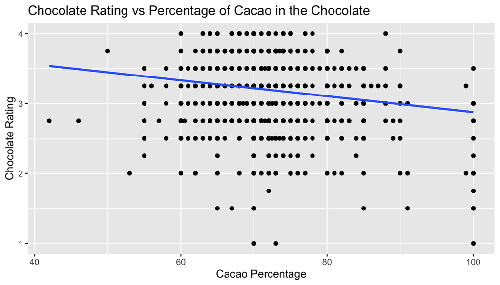

This graph displays the predicted ratings using linear regression using with cacao percentage as the predictor. At 50%, 75%, and 90% cacao percentage, a red, orange, and purple dot marks their predicted rating:

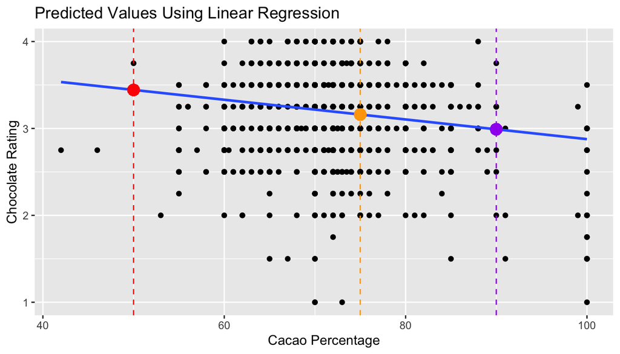

**Confidence Interval**

The 95% confidence interval for our slope is:

```
##                 2.5 %       97.5 %
## num_pcent -0.01434028 -0.008326993
```

We are 95% confident that the true slope lies between -0.01434028 and -0.008326993.

**Correlation Coefficient**

A linear regression model is fitted to the data to quantify the impact of cacao percentage on ratings.The correlation coefficient for the correlation between cacao percentage and ratings is calculated to measure the strength and direction of the linear relationship.

```
## [1] -0.1419967
```

The negative sign indicates an inverse relationship between cacao percentage and rating– as cacao percentage increases, the rating seems to decrease. However, the magnitude of the correlation coefficient is only 0.14, suggesting that cacao percentage is not a strong predictor of a chocolate’s rating.

**Validity of the Linear Regression**

When predicting chocolate ratings from cacao percentage, is linear regression an accurate way to model the data? The residual plot below offers insight into whether linear regression is a good measure of the relationship between cacao percentage and chocolate ratings:

```
## # A tibble: 2,657 × 5
##    pcent  rate num_pcent  resid  pred
##    <chr> <dbl>     <dbl>  <dbl> <dbl>
##  1 76%    3.25        76  0.101  3.15
##  2 76%    3.5         76  0.351  3.15
##  3 76%    3.75        76  0.601  3.15
##  4 68%    3           68 -0.239  3.24
##  5 72%    3           72 -0.194  3.19
##  6 80%    3.25        80  0.147  3.10
##  7 68%    3.5         68  0.261  3.24
##  8 78%    2.75        78 -0.376  3.13
##  9 78%    3           78 -0.126  3.13
## 10 70%    3.5         70  0.283  3.22
## # ℹ 2,647 more rows
```

[figure not shown]

When judging off of the residuals, it appears that this is not a bad linear regression model, there is relatively consistent distribution and spacing of points on either side of the line at 0.

## Discussion

Overall, while cacao percentage can be used with a linear regression to predict the rating of the chocolate as given by this data, with a correlation coefficient of only -0.14, cacao percentage alone may not be the strongest variable to use for this. It is likely that the rating of the chocolate deeply relies on multiple variables and therefore using only one was not able to give a very strong prediction for the final rating.

### Potential Future Directions

**Questions:**

- How might the climate of the regions affect bean production and thus bean quality?
- How can the location of the chocolate company or bean origin have a significant impact on ratings?

**Different methods to address the same questions:**

- Measure relationship between cacao percentage and consumer ratings

**New data to collect to refine our understanding:**

- The ratio of the ingredients listed for each bar
- The net worth of the manufacturers for every different bar of chocolate, perhaps more established chocolate companies produce higher quality chocolate or perhaps they made their money off cheaper, more accessible chocolate for the general public.
- The price of each chocolate bar – is more expensive chocolate higher rated?
- The type of bean used for chocolate– forastero, criollo, and trinitario are the most commonly used types of bean in the chocolate tried by the Manhattan Chocolate Society. Does type of bean affect chocolate rating?

### References

Source of the data: https://flavorsofcacao.com/chocolate_database.html

Chocolate consumption statistic: https://damecacao.com/chocolate-statistics/#:~:text=With%20around%207.7%20billion%20people,pounds%20of%20chocolate%20a%20year!